# csc478_Assignment3

Sojeong Yang  
CSC 478 Assignment 3

## 1. Linear Regression

### a.

**Load and preprocess the data using Pandas or Numpy:**

```python
import numpy as np
import pandas as pd
import matplotlib.pyplot as plt
import pylab as pl
%matplotlib inline

dt = pd.read_csv('./communities/communities.csv', na_values=["?"])
dt
```

|  | state | communityname | population | householdsize | racepctblack | racePctWhite | racePctAsian | racePctHisp | agePct12t21 | agePct12t29 | ... | NumStreet | PctForeignBorn | PctBornSameState | PctSameHouse85 | PctSameCity85 | PctSameState85 | LandArea | PopDens | PctUsePubTrans | ViolentCrimesPerPop |
| --- | --- | --- | --- | --- | --- | --- | --- | --- | --- | --- | --- | --- | --- | --- | --- | --- | --- | --- | --- | --- | --- |
| 0 | 8 | Lakewoodcity | 0.19 | 0.33 | 0.02 | 0.90 | 0.12 | 0.17 | 0.34 | 0.47 | ... | 0.00 | 0.12 | 0.42 | 0.50 | 0.51 | 0.64 | 0.12 | 0.26 | 0.20 | 0.20 |
| 1 | 53 | Tukwilacity | 0.00 | 0.16 | 0.12 | 0.74 | 0.45 | 0.07 | 0.26 | 0.59 | ... | 0.00 | 0.21 | 0.50 | 0.34 | 0.60 | 0.52 | 0.02 | 0.12 | 0.45 | 0.67 |
| 2 | 24 | Aberdeentown | 0.00 | 0.42 | 0.49 | 0.56 | 0.17 | 0.04 | 0.39 | 0.47 | ... | 0.00 | 0.14 | 0.49 | 0.54 | 0.67 | 0.56 | 0.01 | 0.21 | 0.02 | 0.43 |
| 3 | 34 | Willingborotownship | 0.04 | 0.77 | 1.00 | 0.08 | 0.12 | 0.10 | 0.51 | 0.50 | ... | 0.00 | 0.19 | 0.30 | 0.73 | 0.64 | 0.65 | 0.02 | 0.39 | 0.28 | 0.12 |
| 4 | 42 | Bethlehemtownship | 0.01 | 0.55 | 0.02 | 0.95 | 0.09 | 0.05 | 0.38 | 0.38 | ... | 0.00 | 0.11 | 0.72 | 0.64 | 0.61 | 0.53 | 0.04 | 0.09 | 0.02 | 0.03 |
| ... | ... | ... | ... | ... | ... | ... | ... | ... | ... | ... | ... | ... | ... | ... | ... | ... | ... | ... | ... | ... | ... |
| 1989 | 12 | TempleTerracecity | 0.01 | 0.40 | 0.10 | 0.87 | 0.12 | 0.16 | 0.43 | 0.51 | ... | 0.00 | 0.22 | 0.28 | 0.34 | 0.48 | 0.39 | 0.01 | 0.28 | 0.05 | 0.09 |
| 1990 | 6 | Seasidecity | 0.05 | 0.96 | 0.46 | 0.28 | 0.83 | 0.32 | 0.69 | 0.86 | ... | 0.00 | 0.53 | 0.25 | 0.17 | 0.10 | 0.00 | 0.02 | 0.37 | 0.20 | 0.45 |
| 1991 | 9 | Waterburytown | 0.16 | 0.37 | 0.25 | 0.69 | 0.04 | 0.25 | 0.35 | 0.50 | ... | 0.02 | 0.25 | 0.68 | 0.61 | 0.79 | 0.76 | 0.08 | 0.32 | 0.18 | 0.23 |
| 1992 | 25 | Walthamcity | 0.08 | 0.51 | 0.06 | 0.87 | 0.22 | 0.10 | 0.58 | 0.74 | ... | 0.01 | 0.45 | 0.64 | 0.54 | 0.59 | 0.52 | 0.03 | 0.38 | 0.33 | 0.19 |
| 1993 | 6 | Ontariocity | 0.20 | 0.78 | 0.14 | 0.46 | 0.24 | 0.77 | 0.50 | 0.62 | ... | 0.08 | 0.68 | 0.50 | 0.34 | 0.35 | 0.68 | 0.11 | 0.30 | 0.05 | 0.48 |

1994 rows × 100 columns

```python
# load file without "state" and "Communityname" columns

cols = pd.read_csv('./communities/communities.csv', nrows=1).columns
comm_table = pd.read_csv('./communities/communities.csv', usecols=cols[2:], na_values=["?"])
comm_table
```

|  | population | householdsize | racepctblack | racePctWhite | racePctAsian | racePctHisp | agePct12t21 | agePct12t29 | agePct16t24 | agePct65up | ... | NumStreet | PctForeignBorn | PctBornSameState | PctSameHouse85 | PctSameCity85 | PctSameState85 | LandArea | PopDens | PctUsePubTrans | ViolentCrimesPerPop |
| --- | --- | --- | --- | --- | --- | --- | --- | --- | --- | --- | --- | --- | --- | --- | --- | --- | --- | --- | --- | --- | --- |
| 0 | 0.19 | 0.33 | 0.02 | 0.90 | 0.12 | 0.17 | 0.34 | 0.47 | 0.29 | 0.32 | ... | 0.00 | 0.12 | 0.42 | 0.50 | 0.51 | 0.64 | 0.12 | 0.26 | 0.20 | 0.20 |
| 1 | 0.00 | 0.16 | 0.12 | 0.74 | 0.45 | 0.07 | 0.26 | 0.59 | 0.35 | 0.27 | ... | 0.00 | 0.21 | 0.50 | 0.34 | 0.60 | 0.52 | 0.02 | 0.12 | 0.45 | 0.67 |
| 2 | 0.00 | 0.42 | 0.49 | 0.56 | 0.17 | 0.04 | 0.39 | 0.47 | 0.28 | 0.32 | ... | 0.00 | 0.14 | 0.49 | 0.54 | 0.67 | 0.56 | 0.01 | 0.21 | 0.02 | 0.43 |
| 3 | 0.04 | 0.77 | 1.00 | 0.08 | 0.12 | 0.10 | 0.51 | 0.50 | 0.34 | 0.21 | ... | 0.00 | 0.19 | 0.30 | 0.73 | 0.64 | 0.65 | 0.02 | 0.39 | 0.28 | 0.12 |
| 4 | 0.01 | 0.55 | 0.02 | 0.95 | 0.09 | 0.05 | 0.38 | 0.38 | 0.23 | 0.36 | ... | 0.00 | 0.11 | 0.72 | 0.64 | 0.61 | 0.53 | 0.04 | 0.09 | 0.02 | 0.03 |
| ... | ... | ... | ... | ... | ... | ... | ... | ... | ... | ... | ... | ... | ... | ... | ... | ... | ... | ... | ... | ... | ... |
| 1989 | 0.01 | 0.40 | 0.10 | 0.87 | 0.12 | 0.16 | 0.43 | 0.51 | 0.35 | 0.30 | ... | 0.00 | 0.22 | 0.28 | 0.34 | 0.48 | 0.39 | 0.01 | 0.28 | 0.05 | 0.09 |
| 1990 | 0.05 | 0.96 | 0.46 | 0.28 | 0.83 | 0.32 | 0.69 | 0.86 | 0.73 | 0.14 | ... | 0.00 | 0.53 | 0.25 | 0.17 | 0.10 | 0.00 | 0.02 | 0.37 | 0.20 | 0.45 |
| 1991 | 0.16 | 0.37 | 0.25 | 0.69 | 0.04 | 0.25 | 0.35 | 0.50 | 0.31 | 0.54 | ... | 0.02 | 0.25 | 0.68 | 0.61 | 0.79 | 0.76 | 0.08 | 0.32 | 0.18 | 0.23 |
| 1992 | 0.08 | 0.51 | 0.06 | 0.87 | 0.22 | 0.10 | 0.58 | 0.74 | 0.63 | 0.41 | ... | 0.01 | 0.45 | 0.64 | 0.54 | 0.59 | 0.52 | 0.03 | 0.38 | 0.33 | 0.19 |
| 1993 | 0.20 | 0.78 | 0.14 | 0.46 | 0.24 | 0.77 | 0.50 | 0.62 | 0.40 | 0.17 | ... | 0.08 | 0.68 | 0.50 | 0.34 | 0.35 | 0.68 | 0.11 | 0.30 | 0.05 | 0.48 |

1994 rows × 98 columns

```python
comm_table.info()
```

```
<class 'pandas.core.frame.DataFrame'>
RangeIndex: 1994 entries, 0 to 1993
Data columns (total 98 columns):
 #   Column                 Non-Null Count  Dtype
---  ------                 --------------  -----
 0   population             1994 non-null   float64
 1   householdsize          1994 non-null   float64
 2   racepctblack           1994 non-null   float64
 3   racePctWhite           1994 non-null   float64
 4   racePctAsian           1994 non-null   float64
 5   racePctHisp            1994 non-null   float64
 6   agePct12t21            1994 non-null   float64
 7   agePct12t29            1994 non-null   float64
 8   agePct16t24            1994 non-null   float64
 9   agePct65up             1994 non-null   float64
```

[output cut: 90 more lines]

> missing data: 25 OtherPerCap 1993 non-null float64

```python
# switch missing value from Nan to mean value

comm_table.columns[comm_table.isna().any()].tolist()
```

```
['OtherPerCap']
```

```python
comm_table[comm_table.isnull().any(axis=1)]
```

|  | population | householdsize | racepctblack | racePctWhite | racePctAsian | racePctHisp | agePct12t21 | agePct12t29 | agePct16t24 | agePct65up | ... | NumStreet | PctForeignBorn | PctBornSameState | PctSameHouse85 | PctSameCity85 | PctSameState85 | LandArea | PopDens | PctUsePubTrans | ViolentCrimesPerPop |
| --- | --- | --- | --- | --- | --- | --- | --- | --- | --- | --- | --- | --- | --- | --- | --- | --- | --- | --- | --- | --- | --- |
| 130 | 0.02 | 0.38 | 0.98 | 0.22 | 0.01 | 0.01 | 0.44 | 0.4 | 0.27 | 0.58 | ... | 0.0 | 0.01 | 0.84 | 0.7 | 0.83 | 0.77 | 0.04 | 0.12 | 0.05 | 0.23 |

1 rows × 98 columns

```python
comm_table.OtherPerCap[130:135]
```

```
130     NaN
131    0.00
132    0.20
133    0.41
134    0.39
Name: OtherPerCap, dtype: float64
```

```python
comm_table = comm_table.dropna(axis=0)
```

```python
comm_table.OtherPerCap[129:135]
```

```
129    0.00
131    0.00
132    0.20
133    0.41
134    0.39
135    0.45
Name: OtherPerCap, dtype: float64
```

**Compute and display basic staticstics(mean, standard deviation, min, max, etc.) for each of the variables in the data set:**

```python
comm_table.describe(include='all')
```

|  | population | householdsize | racepctblack | racePctWhite | racePctAsian | racePctHisp | agePct12t21 | agePct12t29 | agePct16t24 | agePct65up | ... | NumStreet | PctForeignBorn | PctBornSameState | PctSameHouse85 | PctSameCity85 | PctSameState85 | LandArea | PopDens | PctUsePubTrans | ViolentCrimesPerPop |
| --- | --- | --- | --- | --- | --- | --- | --- | --- | --- | --- | --- | --- | --- | --- | --- | --- | --- | --- | --- | --- | --- |
| count | 1993.000000 | 1993.000000 | 1993.000000 | 1993.000000 | 1993.000000 | 1993.000000 | 1993.000000 | 1993.000000 | 1993.000000 | 1993.000000 | ... | 1993.000000 | 1993.000000 | 1993.000000 | 1993.000000 | 1993.000000 | 1993.000000 | 1993.000000 | 1993.000000 | 1993.000000 | 1993.000000 |
| mean | 0.057612 | 0.463437 | 0.179227 | 0.753984 | 0.153753 | 0.144089 | 0.424210 | 0.493914 | 0.336297 | 0.423086 | ... | 0.022790 | 0.215655 | 0.608776 | 0.534967 | 0.626322 | 0.651470 | 0.065243 | 0.232910 | 0.161741 | 0.237983 |
| std | 0.126935 | 0.163747 | 0.252870 | 0.243807 | 0.208905 | 0.232531 | 0.155234 | 0.143584 | 0.166540 | 0.179196 | ... | 0.100424 | 0.231146 | 0.204314 | 0.181360 | 0.200520 | 0.198253 | 0.109485 | 0.203127 | 0.229099 | 0.233043 |
| min | 0.000000 | 0.000000 | 0.000000 | 0.000000 | 0.000000 | 0.000000 | 0.000000 | 0.000000 | 0.000000 | 0.000000 | ... | 0.000000 | 0.000000 | 0.000000 | 0.000000 | 0.000000 | 0.000000 | 0.000000 | 0.000000 | 0.000000 | 0.000000 |
| 25% | 0.010000 | 0.350000 | 0.020000 | 0.630000 | 0.040000 | 0.010000 | 0.340000 | 0.410000 | 0.250000 | 0.300000 | ... | 0.000000 | 0.060000 | 0.470000 | 0.420000 | 0.520000 | 0.560000 | 0.020000 | 0.100000 | 0.020000 | 0.070000 |
| 50% | 0.020000 | 0.440000 | 0.060000 | 0.850000 | 0.070000 | 0.040000 | 0.400000 | 0.480000 | 0.290000 | 0.420000 | ... | 0.000000 | 0.130000 | 0.630000 | 0.540000 | 0.670000 | 0.700000 | 0.040000 | 0.170000 | 0.070000 | 0.150000 |
| 75% | 0.050000 | 0.540000 | 0.230000 | 0.940000 | 0.170000 | 0.160000 | 0.470000 | 0.540000 | 0.360000 | 0.530000 | ... | 0.000000 | 0.280000 | 0.770000 | 0.660000 | 0.770000 | 0.790000 | 0.070000 | 0.280000 | 0.190000 | 0.330000 |
| max | 1.000000 | 1.000000 | 1.000000 | 1.000000 | 1.000000 | 1.000000 | 1.000000 | 1.000000 | 1.000000 | 1.000000 | ... | 1.000000 | 1.000000 | 1.000000 | 1.000000 | 1.000000 | 1.000000 | 1.000000 | 1.000000 | 1.000000 | 1.000000 |

8 rows × 98 columns

**Separate the target attribute for regression. Create a 20%-80% randomized split of the data. Set aside the 20% test portion:**

```python
# Separeate the target attribute for regression

target = comm_table.ViolentCrimesPerPop
training = comm_table.iloc[:, :97]
target.shape, training.shape
```

```
((1993,), (1993, 97))
```

```python
# Create a 20% test, 80% training
from sklearn.model_selection import train_test_split
x_train, x_test, y_train, y_test = train_test_split(training, target, test_size=0.2, random_state=33)
x_train.shape, x_test.shape, y_train.shape, y_test.shape
```

```
((1594, 97), (399, 97), (1594,), (399,))
```

### b.

**Perform `standard linear regression` on data `using the closed form solution implementation (not the scikit-learn implementation)`:**

```python
# In order to do multiple regression, add a column of 1s as the coefficient for x0
trainX = np.array(x_train)
x = np.array([np.concatenate((v, [1])) for v in trainX])
y = np.array(y_train)

print('x:\n',x)
print('y:\n',y)
print(x.shape, y.shape)
```

```
x:
 [[0.05 0.53 0.31 ... 0.11 0.05 1.  ]
 [0.   0.45 0.41 ... 0.15 0.06 1.  ]
 [0.   0.51 0.02 ... 0.05 0.05 1.  ]
 ...
 [0.08 0.3  0.19 ... 0.17 0.01 1.  ]
 [0.03 0.49 0.52 ... 0.19 0.01 1.  ]
 [0.   0.3  0.01 ... 0.32 0.05 1.  ]]
y:
 [0.31 0.05 0.22 ... 0.6  0.22 0.06]
(1594, 98) (1594,)
```

```python
# standard linear regressioin

def standRegres(xArr, yArr):
    xMat = np.mat(xArr)
    yMat = np.mat(yArr).T
    xTx = xMat.T * xMat
    if np.linalg.det(xTx) == 0.0:
        print("This matrix is singular, cannot do inverse")
        return
    ws = xTx.I * (xMat.T * yMat)
    return ws
```

```python
w = standRegres(x, y)
print(w[:10])
```

```
[[-0.12327412]
 [ 0.0067518 ]
 [ 0.2303801 ]
 [ 0.01190909]
 [ 0.00223185]
 [ 0.1031411 ]
 [ 0.17478597]
 [-0.29568434]
 [-0.15035396]
 [ 0.10632439]]
```

```python
# We have the regression coefficients, compute the predictions
xMat = np.mat(x)
yMat = np.mat(y)
yHat = xMat * w
print(yHat.shape,'\n', yHat[0:10])
```

```
(1594, 1)
 [[ 0.32888552]
 [ 0.25656182]
 [ 0.01018449]
 [-0.04678201]
 [ 0.27344635]
 [ 0.09930385]
 [ 0.34001867]
 [ 0.06481784]
 [ 0.21854776]
 [ 0.16179036]]
```

```python
# Now we can construct an array of errors
err = abs(yHat.T - y)
print(err[:10])
```

```
[[0.01888552 0.20656182 0.20981551 ... 0.24597288 0.06346037 0.02558456]]
```

**Compute the RMSE value on the full training data (the 80% partition):**

```python
# Compute the RMSE value on the full trainin data(the 80% partition)
total_error = np.dot(err, err.T)

rmse_train = np.sqrt(total_error/len(yHat))
print("RMSE value on the full training data: %.8f" %rmse_train)
```

```
RMSE value on the full training data: 0.12752698
```

Plot the correlation between the predicted and actual values of the target attribute.  
Display the obtained regression coefficients (weights) and plot them using matplotlib:

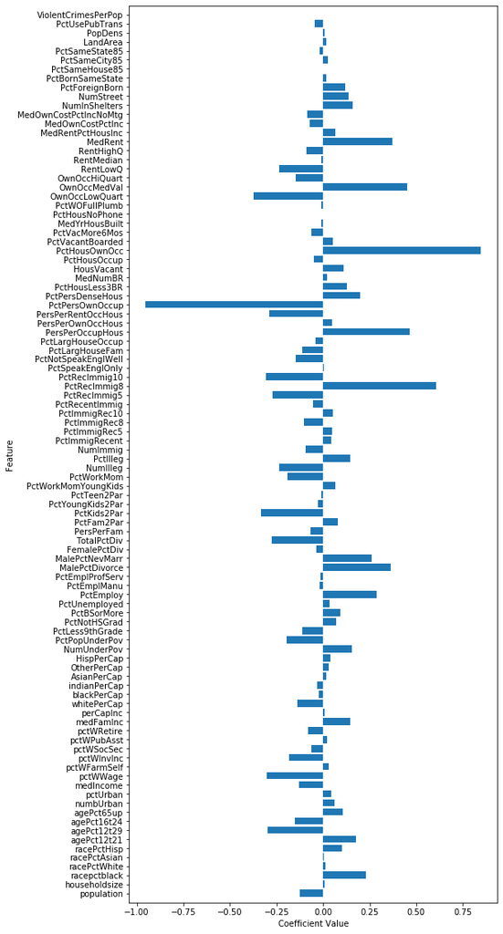

```python
# Plot coeffieients
def plot_coefficients(model, n_features, feature_names):
    labels = np.asarray(w)
    pl.figure(figsize=(8,20))
    pl.barh(range(n_features-1), np.squeeze(labels)[:-1], align='center')
    pl.yticks(np.arange(n_features), feature_names)
    pl.xlabel("Coefficient Value")
    pl.ylabel("Feature")
    pl.ylim(-1, n_features)

comm_feature_names = comm_table.columns.values
plot_coefficients(w, len(comm_feature_names), comm_feature_names)
```

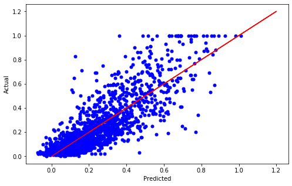

```python
pl.figure(figsize=(8,5))
pl.plot(yHat, y, 'bo', markersize=5)
pl.plot([0,1.2,.2],[0,1.2,.2], 'r-')
pl.xlabel('Predicted')
pl.ylabel('Actual')
pl.show()
```

**Perform 10-fold cross-validation and compare the cross-validation RMSE to the training RMSE (for cross validation, you should use the `KFold` module from `sklearn.model_selection`):**

```python
from sklearn.model_selection import KFold

def cross_validate(model, X, y, n, verbose=False):
    kf = KFold(n_splits=n, shuffle=True, random_state=22)
    xval_err = 0
    f = 1
    for train, test in kf.split(x):
        w = model(x[train], y[train])
        yHat = x[test] * w
        err = abs(yHat.T - y[test])
        total_error = np.dot(err, err.T)
        rmse = np.sqrt(total_error/len(yHat))
        if verbose:
            print("Fold %2d RMSE: %.5f" % (f, rmse))
        xval_err += rmse
        f += 1
    return xval_err/n
```

```python
# 10-fold cross-validation
rmse_10cv = cross_validate(standRegres, x, y, 10, verbose=True)
```

```
Fold  1 RMSE: 0.13298
Fold  2 RMSE: 0.13539
Fold  3 RMSE: 0.12803
Fold  4 RMSE: 0.13711
Fold  5 RMSE: 0.13448
Fold  6 RMSE: 0.13932
Fold  7 RMSE: 0.14338
Fold  8 RMSE: 0.12199
Fold  9 RMSE: 0.13250
Fold 10 RMSE: 0.16545
```

```python
print('RMSE on 10-flod CV: %.8f' %rmse_10cv)
```

```
RMSE on 10-flod CV: 0.13706353
```

```python
print('Standard linear regression')
print('RMSE on training: %.8f' %rmse_train)
print('RMSE on 10-flod CV: %.8f' %rmse_10cv)
```

```
Standard linear regression
RMSE on training: 0.12752698
RMSE on 10-flod CV: 0.13706353
```

### c.

**Feature Selection:**  
**Use the scikit-learn regression model from `sklearn.linear_model` with a subset of features to perform linear regression:**

```python
from sklearn import feature_selection
from sklearn.linear_model  import LinearRegression
```

```python
# Create linear regression object
linreg = LinearRegression()
```

**Write a function that takes as input the training data, target variable, model and returns the optimal percentage of the most informative features to use:**

```python
def featureSeclection(x_train, target, model, cv_num):

    from sklearn.model_selection import cross_val_score
    from sklearn.metrics import mean_absolute_error

    percentiles = range(1, 100, 5)
    results = []
    for i in range(1, 100, 5):
        fs = feature_selection.SelectPercentile(feature_selection.f_regression, percentile=i)
        x_train_fs = fs.fit_transform(x_train, target)
        scores = cross_val_score(model, x_train_fs, target, scoring='neg_mean_absolute_error', cv=cv_num)
        MAE = abs(scores.mean())
        print("%2d %0.7f" %(i, MAE))
        results = np.append(results, MAE)

    return percentiles, results
```

```python
percentiles, results = featureSeclection(x_train, y_train, linreg, 5) # k-fold cross-validatin: k=5

optimal_percentile_ind = np.where(results == results.min())[0][0]
percentiles_feature = percentiles[optimal_percentile_ind]
feature_number = int(percentiles[optimal_percentile_ind]*len(training.columns)/100)
print("\nOptimal percentile of index: {0}".format(optimal_percentile_ind))
print("Optimal percentile of features: {0}".format(percentiles_feature))
print("Optimal number of features: {0}".format(feature_number))
print("Optimal percentile: {0}".format(results[optimal_percentile_ind]))
```

```
 1 0.1131169
 6 0.1016177
11 0.1014361
16 0.1015119
21 0.0994790
26 0.0986606
31 0.0977895
36 0.0972627
41 0.0969453
46 0.0976809
51 0.0975583
56 0.0980912
61 0.0986525
66 0.0988393
71 0.0990267
76 0.0989111
81 0.0986368
86 0.0981176
91 0.0983081
96 0.0973915

Optimal percentile of index: 8
Optimal percentile of features: 41
Optimal number of features: 39
Optimal percentile: 0.0969453231817971
```

**Show the list of most informative variables and their weights:**

```python
# Use optimal percentile of features: 41
fs = feature_selection.SelectPercentile(feature_selection.f_regression, percentile=41)
x_train_fs = fs.fit_transform(x_train, y_train)
print('\t  Variables   Weights')
print('-------------------------------------')
for i in range(len(training.columns.values)):
    if fs.get_support()[i]:
        print("%20s  %3.5f" % (comm_feature_names[i], fs.scores_[i]))
```

```
	  Variables   Weights
-------------------------------------
          population  229.59944
        racepctblack  992.16439
        racePctWhite  1304.88061
           numbUrban  223.61674
           medIncome  341.30957
            pctWWage  170.55413
          pctWInvInc  761.05684
         pctWPubAsst  783.22436
           medFamInc  374.43470
           perCapInc  214.96943
         NumUnderPov  361.95940
      PctPopUnderPov  569.48585
     PctLess9thGrade  296.03204
        PctNotHSGrad  461.05779
         PctBSorMore  169.04179
       PctUnemployed  532.36163
           PctEmploy  196.38436
      MalePctDivorce  580.34201
        FemalePctDiv  693.86270
         TotalPctDiv  677.22866
          PctFam2Par  1596.83917
         PctKids2Par  1901.30015
    PctYoungKids2Par  1269.98247
         PctTeen2Par  1231.32079
            NumIlleg  399.82784
            PctIlleg  1856.84970
     PctLargHouseFam  240.00862
     PctPersOwnOccup  600.09857
    PctPersDenseHous  348.80809
      PctHousLess3BR  446.47829
            MedNumBR  237.21373
          HousVacant  314.72492
        PctHousOccup  167.39221
       PctHousOwnOcc  448.75871
    PctVacantBoarded  489.30119
      PctHousNoPhone  485.84208
      PctWOFullPlumb  229.04098
   MedRentPctHousInc  173.16720
       NumInShelters  246.13472
           NumStreet  176.23838
```

**Plot the model's mean absolute error values on cross-validation:**

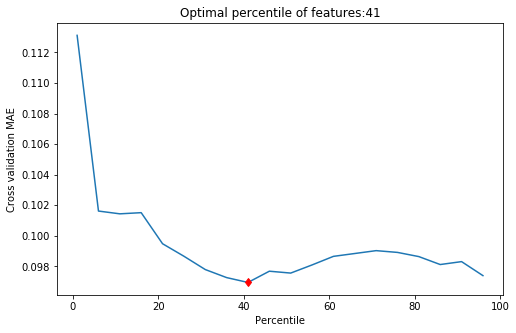

```python
pl.figure(figsize=(8,5))
pl.xlabel("Percentile")
pl.ylabel("Cross validation MAE")
pl.plot(percentiles, results)
plt.plot(percentiles[optimal_percentile_ind], results[optimal_percentile_ind],'rd')
plt.title('Optimal percentile of features:{}'.format(percentiles[optimal_percentile_ind]))
```

**Train your model on the full 80% training data and evalueate it using the 20% test partition:**

```python
from sklearn import metrics

def measure_performance(X, y, model):
    y_pred = model.predict(X)
    MAE = metrics.mean_absolute_error(y, y_pred)
    return MAE
```

```python
linreg.fit(x_train_fs, y_train)
x_test_fs = fs.transform(x_test)

mae = measure_performance(x_test_fs, y_test, linreg)
print('Linear regression >> MAE on the test: {}'.format(mae))
```

```
Linear regression >> MAE on the test: 0.0956476869973062
```

### d.

**Perform** `Ridge Regression` **and** `Lasso Regression` **using the modules from** `sklearn.linear_model.`

```python
from sklearn.linear_model import Ridge, Lasso

def calc_params(X, y, model, param_values, param_name, K):

    # convert input to Numpy arrays
    X = np.array(X)
    y = np.array(y)

    # initialize training/test score arrays with zeros
    train_scores = np.zeros(len(param_values))
    test_scores = np.zeros(len(param_values))

    # iterate over the different prarameter values
    for i, param_value in enumerate(param_values):

        # set model parameters
        model.set_params(**{param_name:param_value})

        # initialize the K scores obtained for each fold
        k_train_scores = np.zeros(K)
        k_test_scores = np.zeros(K)

        # create KFold cross validation
        cv = KFold(n_splits=K, shuffle=True, random_state=0)

        # iterate over the K folds
        j = 0
        for train, test in cv.split(X):

            #fit the model in the corresponding fold
            model.fit(X[train], y[train])

            k_train_scores[j] = measure_performance(X[train], y[train], model)
            k_test_scores[j] = measure_performance(X[test],  y[test], model)
            j += 1

        # store the mean of the K fold scores
        train_scores[i] = np.mean(k_train_scores)
        test_scores[i] = np.mean(k_test_scores)

    # plot the training/test scores
    plt.figure(figsize=(8,5))
    plt.plot(param_values, train_scores, label='Training', alpha=0.4, lw=2, c='b')
    plt.plot(param_values, test_scores, label='CV', alpha=0.4, lw=2, c='g')
    plt.legend()
    plt.xlabel(param_name +' values')
    plt.ylabel("Error")
    plt.title('Mean cross-validation Error')

    min_idx = np.where(test_scores == test_scores.min())
    min_alpha = param_values[min_idx]
    print('Minimun MAE: {}'.format(test_scores[min_idx][0]))
    print('{}: {}'.format(param_name, min_alpha[0]))

    return train_scores, test_scores
```

```python
alpha = np.linspace(.0001, 10, 50)
alpha = np.array([float(e) for e in alpha])
print(alpha)
```

```
[1.00000000e-04 2.04179592e-01 4.08259184e-01 6.12338776e-01
 8.16418367e-01 1.02049796e+00 1.22457755e+00 1.42865714e+00
 1.63273673e+00 1.83681633e+00 2.04089592e+00 2.24497551e+00
 2.44905510e+00 2.65313469e+00 2.85721429e+00 3.06129388e+00
 3.26537347e+00 3.46945306e+00 3.67353265e+00 3.87761224e+00
 4.08169184e+00 4.28577143e+00 4.48985102e+00 4.69393061e+00
 4.89801020e+00 5.10208980e+00 5.30616939e+00 5.51024898e+00
 5.71432857e+00 5.91840816e+00 6.12248776e+00 6.32656735e+00
 6.53064694e+00 6.73472653e+00 6.93880612e+00 7.14288571e+00
 7.34696531e+00 7.55104490e+00 7.75512449e+00 7.95920408e+00
 8.16328367e+00 8.36736327e+00 8.57144286e+00 8.77552245e+00
 8.97960204e+00 9.18368163e+00 9.38776122e+00 9.59184082e+00
 9.79592041e+00 1.00000000e+01]
```

**Ridge Resgression:**

```
Ridge Regression
Minimun MAE: 0.09540913579569754
alpha: 2.040895918367347
```

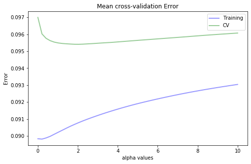

```python
ridge = Ridge()
print('Ridge Regression')
train_scores, test_scores = calc_params(x, y, ridge, alpha, 'alpha', 5)
```

**Lasso Regression:**

```
Lasso Regression
Minimun MAE: 0.0955046077992006
alpha: 0.0001
```

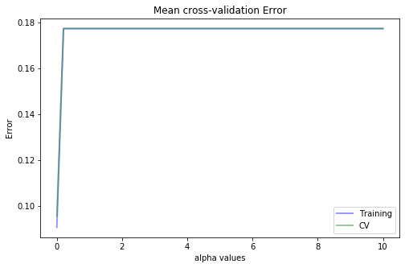

```python
lasso = Lasso()
print('Lasso Regression')
train_scores, test_scores = calc_params(x, y, lasso, alpha, 'alpha', 5)
```

**Using best** `alpha` **values, train the model on the full training data and evaluate it on the test data:**

```python
# Ridge) alpha: 2.040895918367347
# Lasso) alpha: 0.0001

a1 = 2.040895918367347
ridge = Ridge(alpha=a1)
ridge.fit(x_train, y_train)
r_mae = measure_performance(x_test, y_test, ridge)
print("Ridge Regression >> MAE on test: ", r_mae, "\n")

a2 = 0.0001
lasso = Lasso(alpha=a2)
lasso.fit(x_train, y_train)
l_mae = measure_performance(x_test, y_test, lasso)
print("Lasso Regression >> MAE on test: ", l_mae)
```

```
Ridge Regression >> MAE on test:  0.09255857473078784

Lasso Regression >> MAE on test:  0.09299613474547398
```

### e.

**Perform regression using Stochastic Gradient Descent for regression.**

```python
from sklearn.preprocessing import StandardScaler
from sklearn.linear_model import ElasticNet, SGDRegressor
from sklearn.model_selection import GridSearchCV
```

```python
trainX = np.array(x_train)
testX = np.array(x_test)
x = np.array([np.concatenate((v, [1])) for v in trainX])
x_test = np.array([np.concatenate((v, [1])) for v in testX])
target = comm_table['ViolentCrimesPerPop']
```

```python
# standardize features
scaler = StandardScaler()
scaler.fit(x)
x_s = scaler.transform(x)
```

```python
sgdreg = SGDRegressor()
parameters = {
    'penalty': ['l2','l1'],
    'alpha': np.linspace(0.0001, 10, 20)
}
gs = GridSearchCV(sgdreg, parameters, verbose=1, cv=5)
```

```python
%time _ = gs.fit(x_s, y_train)

gs.best_params_, gs.best_score_
```

```
Fitting 5 folds for each of 40 candidates, totalling 200 fits
```

```
[Parallel(n_jobs=1)]: Using backend SequentialBackend with 1 concurrent workers.
```

```
CPU times: user 5.1 s, sys: 44.2 ms, total: 5.14 s
Wall time: 1.3 s
```

```
[Parallel(n_jobs=1)]: Done 200 out of 200 | elapsed:    1.3s finished
```

```
({'alpha': 0.0001, 'penalty': 'l1'}, 0.6431032584344891)
```

```python
sgdreg = SGDRegressor(penalty='l1', alpha=0.0001)

# compute MAE on training data
sgdreg.fit(x_s, y_train)
mae = measure_performance(x_test, y_test, sgdreg)
print('Mean Absoulte Error: {}'.format(mae))
```

```
Mean Absoulte Error: 0.13940578033234374
```

```
Minimun MAE: 0.09639232584577281
l1_ratio: 0.45455454545454543
```

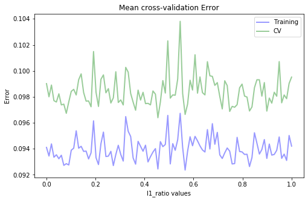

```python
l1_ratio = np.linspace(0.0001, 0.9999, 100)
sgdreg = SGDRegressor(penalty='elasticnet')
train_scores, test_scores = calc_params(x_s, y_train, sgdreg, l1_ratio, 'l1_ratio', 5)
```

**Using the best mixing ratio, apply the Elastic Net model to the set_aside test Data:**

```python
# using l1_ratio: 0.45455454545454543

sgdreg = SGDRegressor(penalty='elasticnet', l1_ratio = 0.45455454545454543)
sgdreg.fit(x_s, y_train)
mae = measure_performance(x_test, y_test, sgdreg)
print('SGDRegressor with Elasticnet >> MAE on test: {}'.format(mae))
```

```
SGDRegressor with Elasticnet >> MAE on test: 0.14421176888260395
```

**Provide a brief summary of your findings from the above experiments:**

- Standard Linear Regression >> MAE on the test: 0.0956476869973062
- Ridge Regression >> MAE on the test: 0.09255857473078784
- Lasso Regression >> MAE on the test: 0.09299613474547398
- SGDRegressor with Elasticnet >> MAE on the test: 0.14421176888260395

The results from above experiments show that using the Ridge regression gives the best performance. Lasso regression is next and SGDRegressor is the last. When I experimented with the different values of alpha, the Ridge regression always shows a minimum value of MAE. Standard Linear regression and Lasso show similar values and SGDRegression always took the last place among four. Elasticnet used l1_ratio parameter that combines both Ridge and Lasso. Elasticnet reduces the impact of different features but it does not delete all of the features. In this experiment, it shows that it doesn't fit the data well. Therefore, using the Ridge regression is the choice to getting a good fit model.

## 2. Automatic Document Clustering

### a.

**Create your own distance function that uses Cosine similarity:**

```python
def cos_sim(x, D):
    a_norm = np.linalg.norm(x)
    b_norm = np.linalg.norm(D)
    sims = np.dot(x, D)/(a_norm * b_norm) # calculate similarity
    dists = 1 - sims
    return dists
```

### b.

**Load the data set:**

```python
TD = pd.read_csv('./newsgroups5/matrix.txt', header=None)
TD
```

|  | 0 | 1 | 2 | 3 | 4 | 5 | 6 | 7 | 8 | 9 | ... | 2490 | 2491 | 2492 | 2493 | 2494 | 2495 | 2496 | 2497 | 2498 | 2499 |
| --- | --- | --- | --- | --- | --- | --- | --- | --- | --- | --- | --- | --- | --- | --- | --- | --- | --- | --- | --- | --- | --- |
| 0 | 0 | 0 | 0 | 0 | 0 | 0 | 0 | 0 | 0 | 0 | ... | 0 | 0 | 0 | 0 | 0 | 0 | 0 | 0 | 0 | 0 |
| 1 | 0 | 0 | 0 | 0 | 0 | 0 | 0 | 0 | 0 | 0 | ... | 0 | 0 | 0 | 0 | 0 | 0 | 0 | 0 | 0 | 0 |
| 2 | 0 | 0 | 0 | 0 | 0 | 0 | 0 | 0 | 0 | 0 | ... | 0 | 0 | 0 | 0 | 0 | 0 | 0 | 0 | 0 | 0 |
| 3 | 0 | 0 | 0 | 0 | 0 | 0 | 0 | 0 | 0 | 0 | ... | 0 | 0 | 0 | 0 | 0 | 0 | 0 | 0 | 0 | 0 |
| 4 | 0 | 0 | 0 | 0 | 0 | 0 | 0 | 0 | 0 | 0 | ... | 0 | 0 | 0 | 0 | 0 | 0 | 0 | 0 | 0 | 0 |
| ... | ... | ... | ... | ... | ... | ... | ... | ... | ... | ... | ... | ... | ... | ... | ... | ... | ... | ... | ... | ... | ... |
| 9323 | 0 | 0 | 0 | 0 | 0 | 0 | 0 | 0 | 0 | 0 | ... | 0 | 0 | 0 | 0 | 0 | 0 | 0 | 0 | 0 | 0 |
| 9324 | 0 | 0 | 0 | 0 | 0 | 0 | 0 | 0 | 0 | 0 | ... | 0 | 0 | 0 | 0 | 0 | 0 | 0 | 0 | 0 | 0 |
| 9325 | 0 | 0 | 0 | 0 | 0 | 0 | 0 | 0 | 0 | 0 | ... | 0 | 0 | 0 | 0 | 0 | 0 | 0 | 0 | 0 | 0 |
| 9326 | 0 | 0 | 0 | 0 | 0 | 0 | 0 | 0 | 0 | 0 | ... | 0 | 0 | 0 | 0 | 0 | 0 | 0 | 0 | 0 | 0 |
| 9327 | 0 | 0 | 0 | 0 | 0 | 0 | 0 | 0 | 0 | 0 | ... | 0 | 0 | 0 | 0 | 0 | 0 | 0 | 0 | 0 | 0 |

9328 rows × 2500 columns

```python
DT = TD.T
DT
```

|  | 0 | 1 | 2 | 3 | 4 | 5 | 6 | 7 | 8 | 9 | ... | 9318 | 9319 | 9320 | 9321 | 9322 | 9323 | 9324 | 9325 | 9326 | 9327 |
| --- | --- | --- | --- | --- | --- | --- | --- | --- | --- | --- | --- | --- | --- | --- | --- | --- | --- | --- | --- | --- | --- |
| 0 | 0 | 0 | 0 | 0 | 0 | 0 | 0 | 0 | 0 | 0 | ... | 0 | 0 | 0 | 0 | 0 | 0 | 0 | 0 | 0 | 0 |
| 1 | 0 | 0 | 0 | 0 | 0 | 0 | 0 | 0 | 0 | 1 | ... | 0 | 0 | 0 | 0 | 0 | 0 | 0 | 0 | 0 | 0 |
| 2 | 0 | 0 | 0 | 0 | 0 | 0 | 0 | 0 | 0 | 0 | ... | 0 | 0 | 0 | 0 | 0 | 0 | 0 | 0 | 0 | 0 |
| 3 | 0 | 0 | 0 | 0 | 0 | 0 | 0 | 0 | 0 | 0 | ... | 0 | 0 | 0 | 0 | 0 | 0 | 0 | 0 | 0 | 0 |
| 4 | 0 | 0 | 0 | 0 | 0 | 0 | 0 | 0 | 0 | 0 | ... | 0 | 0 | 0 | 0 | 0 | 0 | 0 | 0 | 0 | 0 |
| ... | ... | ... | ... | ... | ... | ... | ... | ... | ... | ... | ... | ... | ... | ... | ... | ... | ... | ... | ... | ... | ... |
| 2495 | 0 | 0 | 0 | 0 | 0 | 0 | 0 | 0 | 0 | 0 | ... | 0 | 0 | 0 | 0 | 0 | 0 | 0 | 0 | 0 | 0 |
| 2496 | 0 | 0 | 0 | 0 | 0 | 0 | 0 | 0 | 0 | 0 | ... | 0 | 0 | 0 | 0 | 0 | 0 | 0 | 0 | 0 | 0 |
| 2497 | 0 | 0 | 0 | 0 | 0 | 0 | 0 | 0 | 0 | 0 | ... | 0 | 0 | 0 | 0 | 0 | 0 | 0 | 0 | 0 | 0 |
| 2498 | 0 | 0 | 0 | 0 | 0 | 0 | 0 | 0 | 0 | 0 | ... | 0 | 0 | 0 | 0 | 0 | 0 | 0 | 0 | 0 | 0 |
| 2499 | 0 | 0 | 0 | 0 | 0 | 0 | 0 | 0 | 0 | 0 | ... | 0 | 0 | 0 | 0 | 0 | 0 | 0 | 0 | 0 | 0 |

2500 rows × 9328 columns

```python
terms = pd.read_csv('./newsgroups5/terms.txt', header=None)
terms
```

|  | 0 |
| --- | --- |
| 0 | aa |
| 1 | aargh |
| 2 | aaron |
| 3 | aaronc |
| 4 | ab |
| ... | ... |
| 9323 | zubov |
| 9324 | zv |
| 9325 | zw |
| 9326 | zx |
| 9327 | zz |

9328 rows × 1 columns

```python
classes = pd.read_csv('./newsgroups5/classes.txt', header=None, index_col=0, skiprows=1, delimiter=' ')
classes
```

| 0 | 1 |
| --- | --- |
| 0 | 0 |
| 1 | 1 |
| 2 | 1 |
| 3 | 1 |
| 4 | 2 |
| ... | ... |
| 2495 | 4 |
| 2496 | 4 |
| 2497 | 3 |
| 2498 | 4 |
| 2499 | 2 |

2500 rows × 1 columns

```python
numTerms = terms.shape[0]
NDocs = TD.shape[1]
numTerms, NDocs
```

```
(9328, 2500)
```

```python
# doc counts for each term
DF = pd.DataFrame([(TD!=0).sum(1)]).T
DF
```

|  | 0 |
| --- | --- |
| 0 | 10 |
| 1 | 6 |
| 2 | 22 |
| 3 | 9 |
| 4 | 13 |
| ... | ... |
| 9323 | 6 |
| 9324 | 5 |
| 9325 | 3 |
| 9326 | 3 |
| 9327 | 4 |

9328 rows × 1 columns

```python
# Create a matrix with all entries = NDocs
NMatrix = np.ones(np.shape(TD), dtype=float)*NDocs
np.set_printoptions(precision=2, suppress=True, linewidth=120)
print(NMatrix)
```

```
[[2500. 2500. 2500. ... 2500. 2500. 2500.]
 [2500. 2500. 2500. ... 2500. 2500. 2500.]
 [2500. 2500. 2500. ... 2500. 2500. 2500.]
 ...
 [2500. 2500. 2500. ... 2500. 2500. 2500.]
 [2500. 2500. 2500. ... 2500. 2500. 2500.]
 [2500. 2500. 2500. ... 2500. 2500. 2500.]]
```

```python
# Convert each entry into IDF values
IDF = np.log2(np.divide(NMatrix, np.array(DF)))
print(IDF)
```

```
[[7.97 7.97 7.97 ... 7.97 7.97 7.97]
 [8.7  8.7  8.7  ... 8.7  8.7  8.7 ]
 [6.83 6.83 6.83 ... 6.83 6.83 6.83]
 ...
 [9.7  9.7  9.7  ... 9.7  9.7  9.7 ]
 [9.7  9.7  9.7  ... 9.7  9.7  9.7 ]
 [9.29 9.29 9.29 ... 9.29 9.29 9.29]]
```

```python
# Finally compute the TFxIDF for each doc-term entry
TD_tfidf = TD * IDF

DT_tfidf = TD_tfidf.T

DT_tfidf = np.array(DT_tfidf)
terms = np.array(terms)
classes = np.array(classes)
```

**Split the dataset and set aside 20% for later use:**

```python
DT_train, DT_test, c_train, c_test = train_test_split(DT_tfidf, classes, test_size=0.2, random_state=99)
DT_train.shape, DT_test.shape, c_train.shape, c_test.shape
```

```
((2000, 9328), (500, 9328), (2000, 1), (500, 1))
```

### c.

**Perform Kmeans clustering on the training data. Wrtie a function to display the top N terms in each cluster:**

```python
from sklearn.cluster import KMeans
import kMeans
```

```python
def display_clusters(data, clusterSize, numTerms):

    centroids, clusters = kMeans.kMeans(data, clusterSize, cos_sim, kMeans.randCent)
    c_list = pd.DataFrame()

    for c in range(clusterSize):
        docs_classes = data[clusters[:,0] == c] # make the document in each cluster
        doc_term_freq = (docs_classes != 0).sum(0)     # DT frequency
        doc_num = len(docs_classes)
        centroid = pd.Series(centroids[c], name='c_value')

        print("CLUSTER: ", c, " results")
        print("Number of documents in cluster: ", doc_num)

        cluster_rep = pd.DataFrame()
        cluster_rep['word'] = terms.ravel()
        cluster_rep['frequency'] = centroid
        cluster_rep['DF'] = doc_term_freq
        cluster_rep['PercentofDocs'] = (doc_term_freq*100.0/doc_num)
        cluster_rep = cluster_rep.sort_values(by='DF',ascending=False)[['word','frequency','DF','PercentofDocs']]

        print(cluster_rep.head(numTerms))
        print('----------------------------------------------------')

        t1 = cluster_rep[cluster_rep['DF']!=0][['DF','word']]
        t2 = np.ones((len(t1),1))*c
        t1['clst'] = t2
        c_list = c_list.append(t1)

    return centroids, clusters, c_list
```

```python
centroids, clusters, c_list = display_clusters(DT_train, 5, 10)
```

```
CLUSTER:  0  results
Number of documents in cluster:  398
           word  frequency   DF  PercentofDocs
9129      write   0.903181  249      62.562814
3345        god   7.634015  222      55.778894
5795         on   2.001077  219      55.025126
417      articl   0.930496  190      47.738693
1335  christian   4.940925  180      45.226131
6049      peopl   2.492601  174      43.718593
4449       know   1.520615  170      42.713568
8203      think   1.470829  160      40.201005
693      believ   2.377771  156      39.195980
4319       just   1.136950  149      37.437186
----------------------------------------------------
CLUSTER:  1  results
```

[output cut: 55 more lines]

```
Word Cloud >> CLUSTER: 0
```

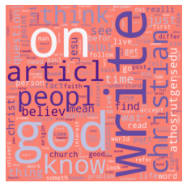

```
Word Cloud >> CLUSTER: 1
```

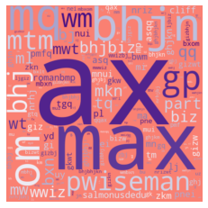

```
Word Cloud >> CLUSTER: 2
```

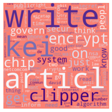

```
Word Cloud >> CLUSTER: 3
```

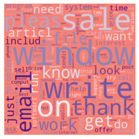

```
Word Cloud >> CLUSTER: 4
```

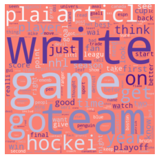

```python
from wordcloud import WordCloud

for i in range (5):
    dic = {}
    print("Word Cloud >> CLUSTER: {}".format(i))
    word_freq = c_list[c_list['clst'] == i]
    for k, v in word_freq[['word','DF']].values:
        dic[k] = int(v)

    wordcloud = WordCloud(width=480, height=480,
                          background_color="salmon",
                          colormap="Purples").generate_from_frequencies(dic)
    plt.figure()
    plt.imshow(wordcloud, interpolation="bilinear")
    plt.axis("off")
    plt.margins(x=0, y=0)
    plt.show()
```

### d.

**Compare your 5 cluster to the 5 pre-assigned classes by computing the Completeness and Homogeneity values:**

```python
centroids
```

```
array([[0.06, 0.  , 1.22, ..., 0.05, 0.05, 0.26],
       [0.  , 0.  , 0.  , ..., 1.39, 0.  , 0.  ],
       [0.  , 0.  , 0.  , ..., 0.  , 0.  , 0.  ],
       [0.05, 0.  , 0.05, ..., 0.  , 0.  , 0.  ],
       [0.  , 0.13, 0.  , ..., 0.  , 0.  , 0.  ]])
```

```python
clusters = clusters.T[0]
clusters
```

```
array([2., 3., 3., ..., 4., 0., 3.])
```

```python
c_train2 = np.array(c_train)
c_train2.shape
```

```
(2000, 1)
```

```python
from sklearn.metrics import completeness_score, homogeneity_score

completeness = completeness_score(np.array(c_train2.T)[0],clusters)
homogeneity = homogeneity_score(np.array(c_train2.T)[0],clusters)

print('Completeness: {} '.format(completeness))
print('Homogeneity: {}'.format(homogeneity))
```

```
Completeness: 0.8326617187102768
Homogeneity: 0.6997970294706858
```

### e.

**Categorize each of the documents in the 20% set-aside data into each of the appropriate cluster:**

```python
res = []

for d in DT_test:
    dic = {}   # dictionary
    cossim = []
    num = 0
    for c in centroids:
        centroid_sim = 1 - cos_sim(d, c)
        cossim.append(centroid_sim)
        dic['Cluster {}'.format(num)] = centroid_sim
        num += 1
    dic['Predicted Cluster'] = cossim.index(max(cossim))
    res.append(dic)
show_res = pd.DataFrame(res)
show_res.head(10)
```

|  | Cluster 0 | Cluster 1 | Cluster 2 | Cluster 3 | Cluster 4 | Predicted Cluster |
| --- | --- | --- | --- | --- | --- | --- |
| 0 | 0.075741 | 0.000005 | 0.264433 | 0.091009 | 0.062160 | 2 |
| 1 | 0.052788 | 0.000000 | 0.110915 | 0.080444 | 0.041622 | 2 |
| 2 | 0.055804 | 0.000035 | 0.080001 | 0.188489 | 0.033993 | 3 |
| 3 | 0.019102 | 0.000004 | 0.119539 | 0.019150 | 0.014458 | 2 |
| 4 | 0.260102 | 0.000006 | 0.077077 | 0.079253 | 0.055502 | 0 |
| 5 | 0.044736 | 0.000013 | 0.050657 | 0.049439 | 0.258098 | 4 |
| 6 | 0.267210 | 0.000009 | 0.099093 | 0.083329 | 0.077456 | 0 |
| 7 | 0.121680 | 0.000000 | 0.045399 | 0.032487 | 0.023001 | 0 |
| 8 | 0.024776 | 0.000009 | 0.024646 | 0.038269 | 0.195948 | 4 |
| 9 | 0.252758 | 0.000015 | 0.073186 | 0.072355 | 0.059676 | 0 |